# Question 2 - Topic Modelling of News Articles with LDA

R.P Molefe (EDUV4838900)

2026-11-14

# Question 2.1 - Data frame (file_name, content) and denoising

```r
# Q2.1
unzip("news.zip", exdir = "news", overwrite = TRUE)
files <- list.files("news", recursive = TRUE, full.names = TRUE)
files <- files[!grepl("(__MACOSX|/\\.)", files)]

news_df <- tibble(
  file_name = basename(files),
  content   = map_chr(files, ~ paste(readLines(.x, warn = FALSE, encoding = "UTF-8"), collapse = " "))
)
cat("Documents loaded:", nrow(news_df), "\n")
```

```
## Documents loaded: 10
```

```r
head(news_df |> mutate(content = substr(content, 1, 120)))
```

```
## # A tibble: 6 × 2
##   file_name   content
##   <chr>       <chr>
## 1 news_1.txt  Eskom former official, service provider appear in court Tuesday, …
## 2 news_10.txt Wet, cold weather expected to continue in Western Cape Monday, Ju…
## 3 news_2.txt  Gauteng Education commits to implementing Mayibuye Primary School…
## 4 news_3.txt  New Labour Minister charts the way forward  Tuesday, July 9, 2024…
## 5 news_4.txt  Police recue two kidnapped victims in Benoni Tuesday, July 9, 202…
## 6 news_5.txt  President Ramaphosa sends condolences to deceased SANDF members T…
```

The following denoising techniques were applied: transliteration of non-ASCII characters, lower-casing, removal of URLs, e-mail addresses, HTML tags, numbers and punctuation, whitespace normalisation, removal of empty and duplicate documents, stop-word removal (standard and domain-specific news words), removal of tokens shorter than three characters, and lemmatisation.

```r
# Q2.1
clean_text <- function(x) {
  x |>
    iconv(to = "ASCII//TRANSLIT", sub = " ") |>
    tolower() |>
    str_replace_all("http\\S+|www\\.\\S+|\\S+@\\S+", " ") |>
    str_replace_all("<[^>]+>", " ") |>
    str_replace_all("[0-9]+", " ") |>
    str_replace_all("[[:punct:]]", " ") |>
    str_squish()
}

news_df <- news_df |>
  mutate(clean = clean_text(content)) |>
  filter(nchar(clean) > 50) |>
  distinct(clean, .keep_all = TRUE)

custom_stop <- tibble(word = c("said","say","mr","mrs","also","will","year","new","one","two",
                               "can","just","like","get","told","people"))
tokens <- news_df |>
  unnest_tokens(word, clean) |>
  anti_join(stop_words, by = "word") |>
  anti_join(custom_stop, by = "word") |>
  filter(nchar(word) > 2) |>
  mutate(word = lemmatize_words(word))

cat("Documents after cleaning:", n_distinct(tokens$file_name), " | Tokens:", nrow(tokens), "\n")
```

```
## Documents after cleaning: 10  | Tokens: 1926
```

```r
tokens |> count(word, sort = TRUE) |> head(15)
```

```
## # A tibble: 15 × 2
##    word               n
##    <chr>          <int>
##  1 department        34
##  2 government        29
##  3 service           28
##  4 public            26
##  5 invoice           18
##  6 south             18
##  7 coalition         17
##  8 national          17
##  9 day               14
## 10 pay               13
## 11 report            13
## 12 administration    12
## 13 africa            12
## 14 country           12
## 15 eskom             12
```

# Question 2.2 - LDA: top n topics and top k words

## Number of topics

```r
# Q2.2
dtm <- tokens |> count(file_name, word) |> cast_dtm(file_name, word, n)
dtm <- removeSparseTerms(dtm, 0.99)
dtm <- dtm[row_sums(dtm) > 0, ]
dtm
```

```
## <<DocumentTermMatrix (documents: 10, terms: 866)>>
## Non-/sparse entries: 1177/7483
## Sparsity           : 86%
## Maximal term length: 19
## Weighting          : term frequency (tf)
```

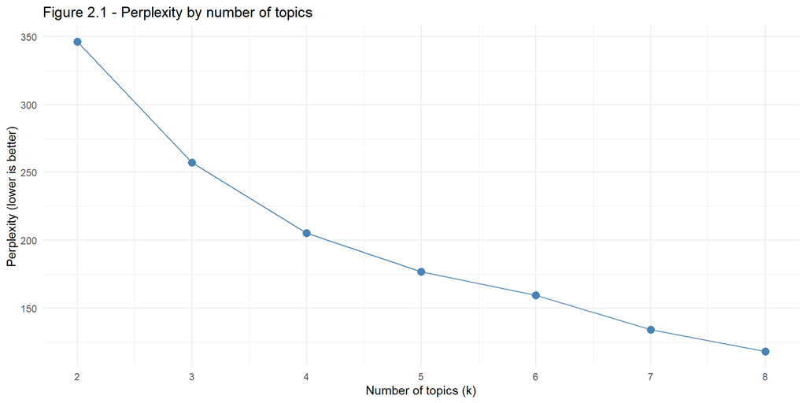

```r
# Q2.2
ks <- 2:8
perp <- sapply(ks, function(k) perplexity(LDA(dtm, k = k, control = list(seed = 1234))))
tune <- tibble(topics = ks, perplexity = perp)
ggplot(tune, aes(topics, perplexity)) +
  geom_line(colour = "steelblue") + geom_point(size = 3, colour = "steelblue") +
  scale_x_continuous(breaks = ks) +
  labs(title = "Figure 2.1 - Perplexity by number of topics",
       x = "Number of topics (k)", y = "Perplexity (lower is better)") +
  theme_minimal()
```

```r
tune
```

```
## # A tibble: 7 × 2
##   topics perplexity
##    <int>      <dbl>
## 1      2       346.
## 2      3       257.
## 3      4       205.
## 4      5       177.
## 5      6       160.
## 6      7       134.
## 7      8       118.
```

## LDA model

```r
# Q2.2
n_topics <- 5
k_words  <- 10

lda <- LDA(dtm, k = n_topics, method = "Gibbs",
           control = list(seed = 1234, iter = 1000, burnin = 200))

beta  <- tidy(lda, matrix = "beta")
gamma <- tidy(lda, matrix = "gamma")

top_terms <- beta |> group_by(topic) |> slice_max(beta, n = k_words, with_ties = FALSE) |>
  arrange(topic, desc(beta)) |> ungroup()
```

## Top k words per topic

```r
# Q2.2
top_terms |>
  group_by(topic) |>
  mutate(rank = row_number(), word = paste0(term, " (", round(beta, 3), ")")) |>
  ungroup() |>
  select(rank, topic, word) |>
  pivot_wider(names_from = topic, values_from = word, names_prefix = "Topic ") |>
  knitr::kable(caption = "Top words per topic with beta (word probability) in brackets")
```

Top words per topic with beta (word probability) in brackets

| rank | Topic 1 | Topic 2 | Topic 3 | Topic 4 | Topic 5 |
| --- | --- | --- | --- | --- | --- |
| 1 | service (0.05) | government (0.058) | department (0.045) | eskom (0.031) | police (0.023) |
| 2 | public (0.043) | coalition (0.036) | priority (0.02) | report (0.031) | expect (0.017) |
| 3 | invoice (0.032) | administration (0.019) | ensure (0.018) | south (0.021) | cape (0.017) |
| 4 | day (0.025) | include (0.017) | unemployment (0.018) | school (0.021) | cold (0.015) |
| 5 | department (0.025) | role (0.017) | continue (0.016) | action (0.018) | weather (0.015) |
| 6 | pay (0.023) | power (0.013) | meth (0.016) | result (0.016) | west (0.015) |
| 7 | psc (0.022) | governance (0.013) | south (0.014) | tuesday (0.016) | western (0.015) |
| 8 | gxoyiya (0.02) | policy (0.013) | development (0.011) | employee (0.013) | sandf (0.013) |
| 9 | national (0.018) | relationship (0.013) | build (0.011) | investigation (0.013) | team (0.011) |
| 10 | provider (0.016) | finlay (0.011) | employment (0.011) | conduct (0.013) | force (0.011) |

## Word distribution per topic

```r
# Q2.2
top_terms |> group_by(topic) |>
  summarise(top_k_probability_mass = round(sum(beta), 3),
            words = paste(term, collapse = ", ")) |>
  knitr::kable(caption = "Share of each topic's probability carried by its top words")
```

Share of each topic’s probability carried by its top words

| topic | top_k_probability_mass | words |
| --- | --- | --- |
| 1 | 0.274 | service, public, invoice, day, department, pay, psc, gxoyiya, national, provider |
| 2 | 0.208 | government, coalition, administration, include, role, power, governance, policy, relationship, finlay |
| 3 | 0.180 | department, priority, ensure, unemployment, continue, meth, south, development, build, employment |
| 4 | 0.194 | eskom, report, south, school, action, result, tuesday, employee, investigation, conduct |
| 5 | 0.150 | police, expect, cape, cold, weather, west, western, sandf, team, force |

```r
gamma |> group_by(topic) |> summarise(avg_document_share = round(mean(gamma), 3)) |>
  arrange(desc(avg_document_share)) |>
  knitr::kable(caption = "Topic prevalence across the corpus")
```

Topic prevalence across the corpus

| topic | avg_document_share |
| --- | --- |
| 1 | 0.250 |
| 5 | 0.229 |
| 4 | 0.193 |
| 3 | 0.165 |
| 2 | 0.163 |

## Findings

The corpus consists of 10 South African news articles. After denoising, 1926 meaningful tokens remained, and the most frequent terms were *department (34), government (29), service (28), public (26), invoice (18)*, which reflects the dominant subject matter of the collection.

Perplexity was calculated for models with 2 to 8 topics; the lowest perplexity was obtained at k = 8 (118.4). A 5-topic model was retained because, for a small corpus of 10 articles, it balances statistical fit with topics that remain distinct and interpretable.

The word distribution per topic is summarised below:

- **Topic 1** is characterised by *service, public, invoice, day, department*. Its top 10 words carry 27.4% of the topic’s probability mass, the topic accounts for 25.0% of the corpus on average and it is the dominant topic in 3 article(s).
- **Topic 2** is characterised by *government, coalition, administration, include, role*. Its top 10 words carry 20.8% of the topic’s probability mass, the topic accounts for 16.3% of the corpus on average and it is the dominant topic in 1 article(s).
- **Topic 3** is characterised by *department, priority, ensure, unemployment, continue*. Its top 10 words carry 18.0% of the topic’s probability mass, the topic accounts for 16.5% of the corpus on average and it is the dominant topic in 1 article(s).
- **Topic 4** is characterised by *eskom, report, south, school, action*. Its top 10 words carry 19.4% of the topic’s probability mass, the topic accounts for 19.3% of the corpus on average and it is the dominant topic in 2 article(s).
- **Topic 5** is characterised by *police, expect, cape, cold, weather*. Its top 10 words carry 15.0% of the topic’s probability mass, the topic accounts for 22.9% of the corpus on average and it is the dominant topic in 3 article(s).

Topic 1 is the most prevalent theme in the collection (25.0% average share), which indicates that it is the subject most frequently reported on in these articles.

# Question 2.3 - Visualisations

## Visualisation 1 - Top words per topic

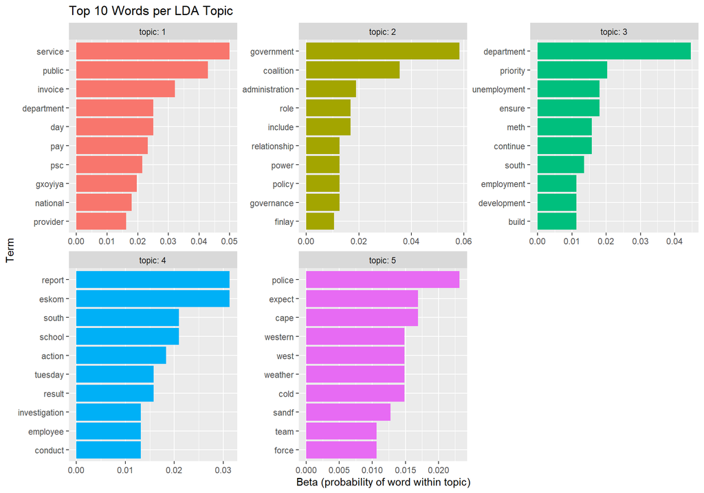

```r
# Q2.3
top_terms |>
  mutate(term = reorder_within(term, beta, topic)) |>
  ggplot(aes(beta, term, fill = factor(topic))) +
  geom_col(show.legend = FALSE) +
  facet_wrap(~ topic, scales = "free", labeller = label_both) +
  scale_y_reordered() +
  labs(title = "Top 10 Words per LDA Topic", x = "Beta (probability of word within topic)", y = "Term")
```

## Visualisation 2 - Word cloud per topic

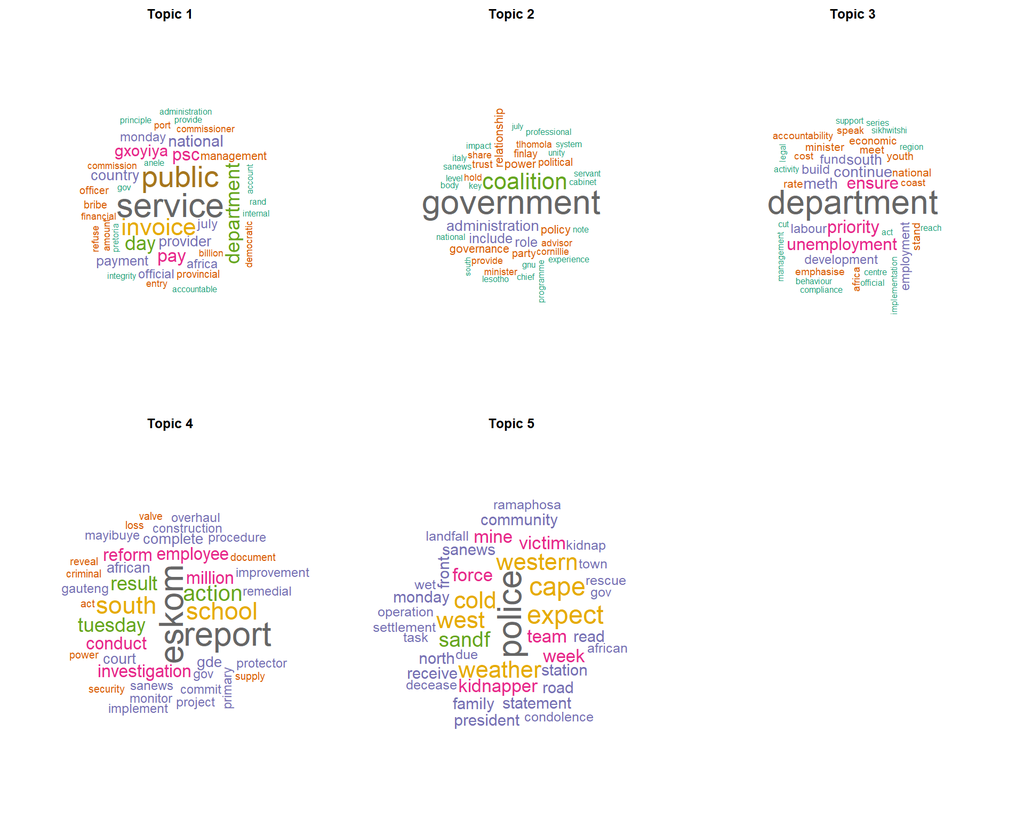

```r
# Q2.3
par(mfrow = c(2, ceiling(n_topics / 2)), mar = c(0, 0, 2, 0))
for (t in seq_len(n_topics)) {
  d <- beta |> filter(topic == t) |> slice_max(beta, n = 40, with_ties = FALSE)
  wordcloud(d$term, d$beta, scale = c(3, 0.5), colors = brewer.pal(8, "Dark2"), random.order = FALSE)
  title(paste("Topic", t))
}
```

## Visualisation 3 - Word-topic heat map

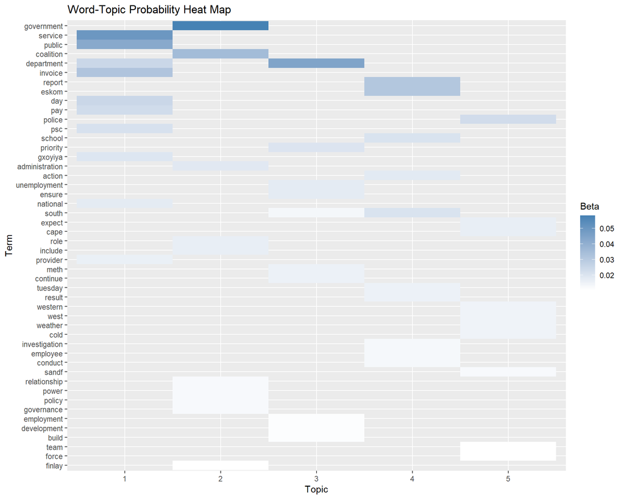

```r
# Q2.3
top_terms |>
  ggplot(aes(factor(topic), reorder(term, beta), fill = beta)) +
  geom_tile() +
  scale_fill_gradient(low = "white", high = "steelblue") +
  labs(title = "Word-Topic Probability Heat Map", x = "Topic", y = "Term", fill = "Beta")
```

## Findings

The bar charts and word clouds show the highest-probability word in each topic: Topic 1 - *service* (beta = 0.050); Topic 2 - *government* (beta = 0.058); Topic 3 - *department* (beta = 0.045); Topic 4 - *eskom* (beta = 0.031); Topic 5 - *police* (beta = 0.023). The larger the bar or the word in the cloud, the more strongly that word defines the topic.

The heat map shows that 2 word(s) (*department, south*) rank among the top words of more than one topic, which indicates some overlap between these themes, while the remaining words are specific to a single topic and make the topics clearly distinguishable.